# Talking Battle of Smart Phones

Aditya Gore

July 21, 2016

# Talking Data - Battle of Smart Phones

# Benchmark performance

## Equal weights to all the groups

The benchmark logloss value is 2.4849066.

# Demographic features

## Distribution by Groups

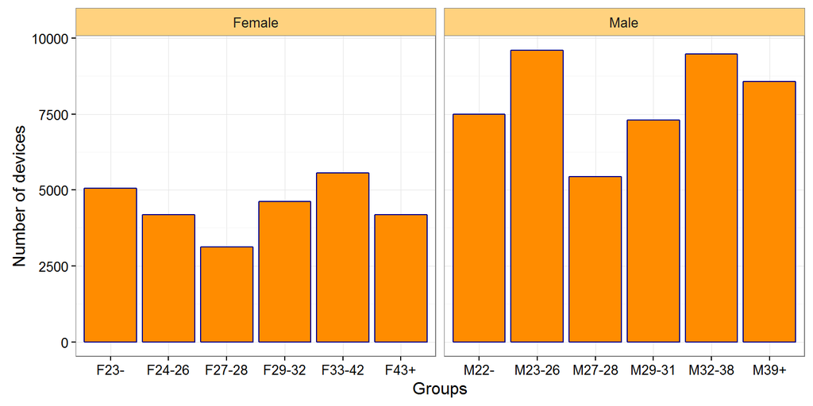

## Distribuiton by Gender

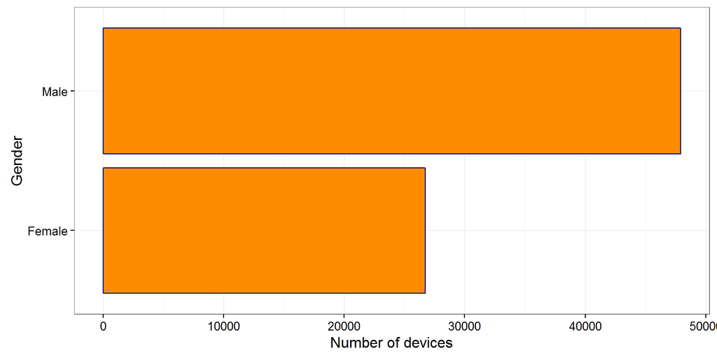

## Distribuiton by Age

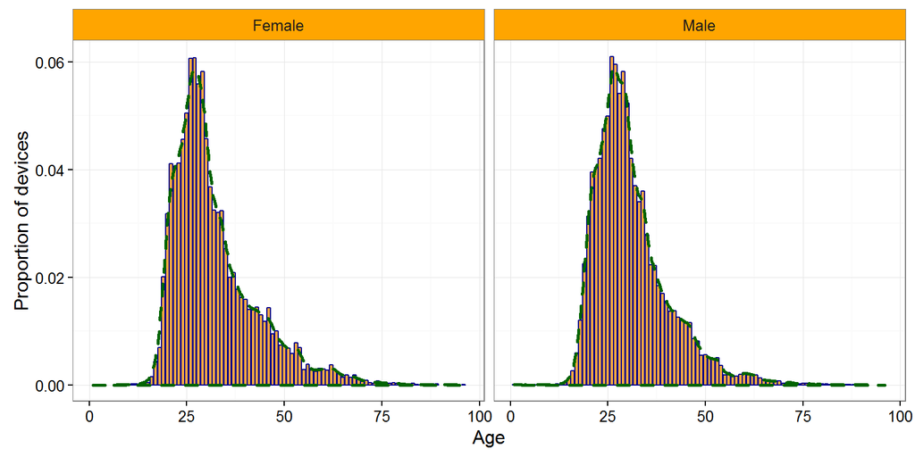

This distribution of device across age group for two genders appear to be same.

# Prediction using demographic features

## Simple count of groups

This method results in the logloss of 2.428037.

# Using Brand information

There are 523 pure duplicate entries in the brand file.

After removing those duplicate entries there remain 6 duplicate devices.

| device_id | Brand 1 | Brand 2 |
| --- | --- | --- |
| -3004353610608679970 | 5891 | 7296 |
| -5269721363279128080 | Galaxy Core Advance | MI 3 |
| -6590454305031525112 | MI 3 | 6 Plus |
| -7059081542575379359 | LG Nexus 5 | Note 2 |
| -7297178577997113203 | 5X | 3C |
| 5245428108336915020 | MX4 | MI One Plus |

As pointed out by ``dune_dweller’’ there are multiple phone models that carry the same type of device models.

| unique_brands | devices |
| --- | --- |
| 1 | 1544 |
| 2 | 43 |
| 3 | 8 |
| 4 | 3 |

Therefore the device models are prefixed with phone brand to create unique identifiers for the models. Only one device from this multiple brands will be kept for the purpose of this analysis.

## Number of unique brands by groups

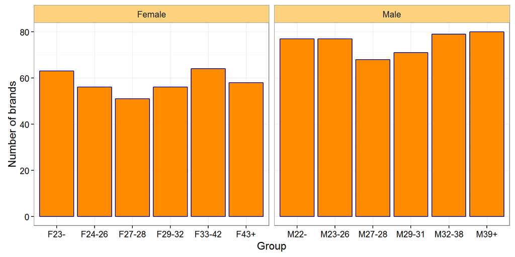

## Number of unique models by groups

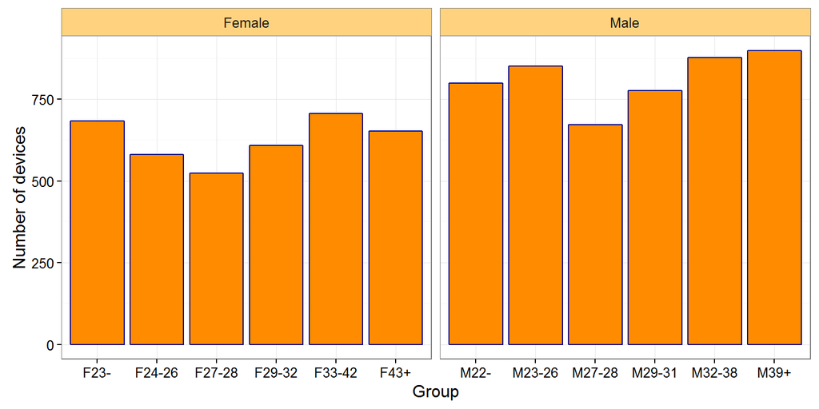

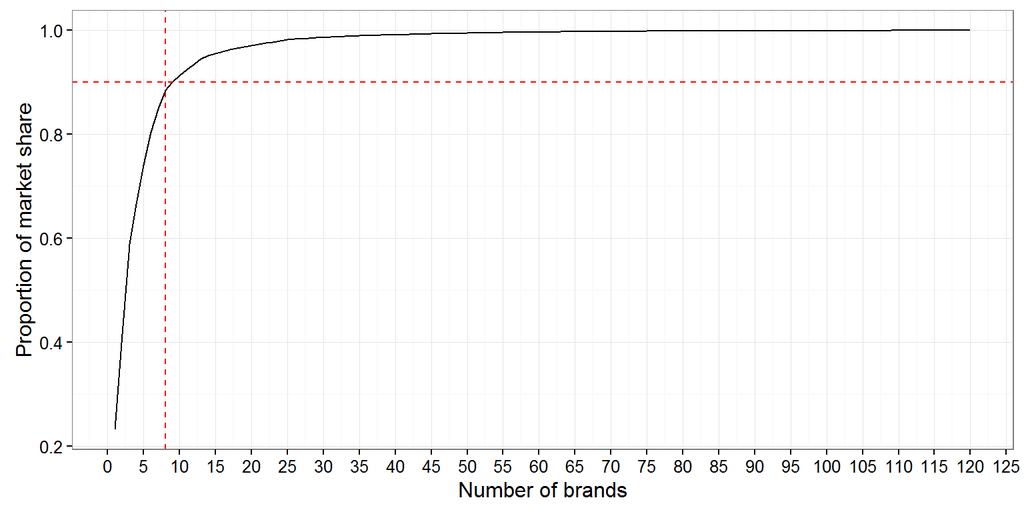

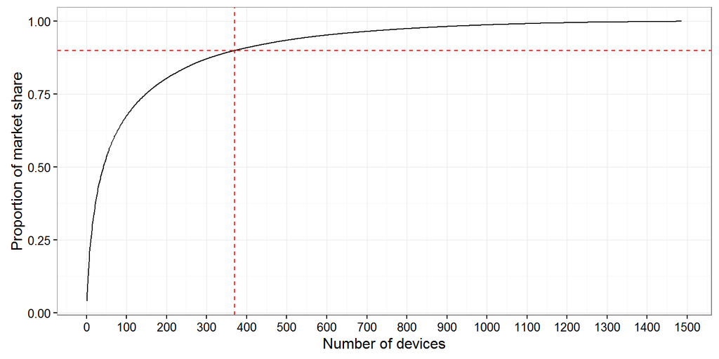

## Distribution of top 10 brands by gender

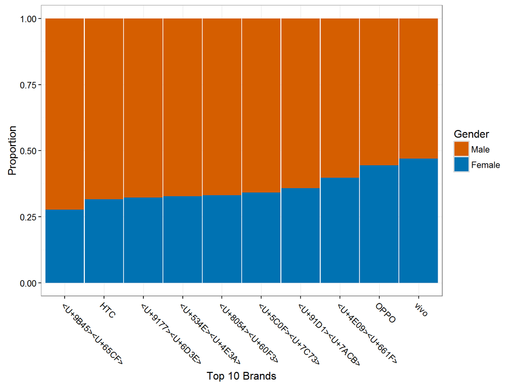

## Distribution of top 10 brands across age

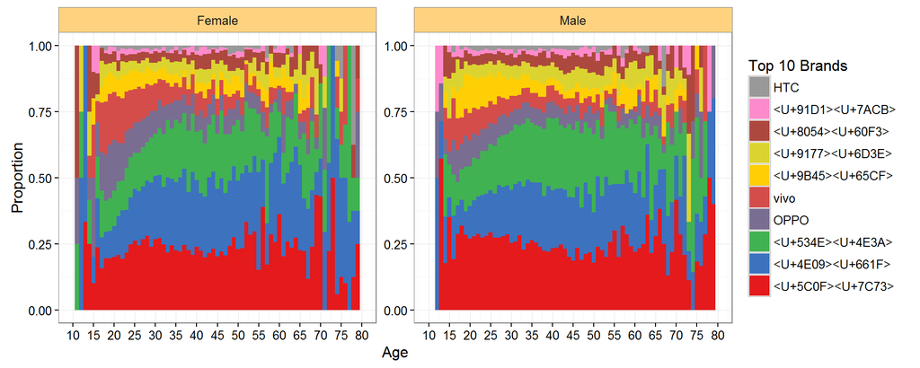

## Distribution across target groups

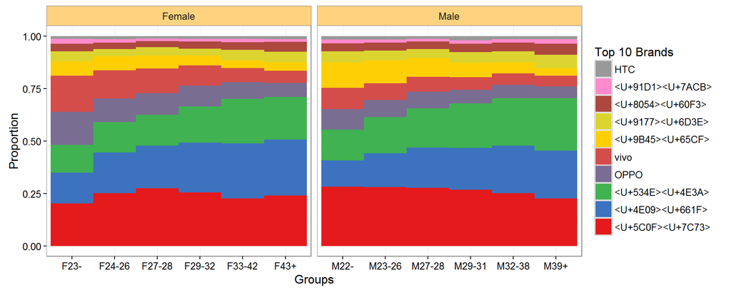

The distribution of top 10 brands show a pattern across these groups.

## Prediction using phone brands:

```
## [1] "probfit"
```

```
## [1] "probfit"
```

```
## [1] "predict.featuremodel"
```

```
## [1] "predict.featuremodel"
```

```
## [1] 2.586139
```

Neither does the naive bayes approach with device model as a predictor which has a logloss value of 2.4280319.